# **Red Wine Exploration by Dominic Del Rosario**

### Final Plots and Summary

**Plot One**

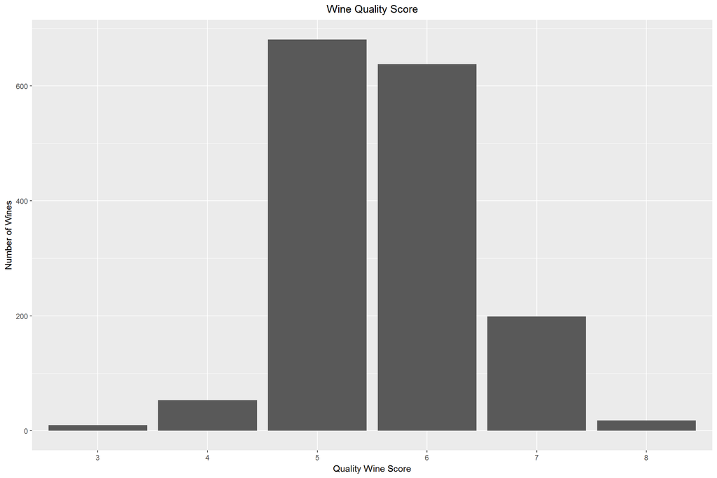

```
##    Min. 1st Qu.  Median    Mean 3rd Qu.    Max.
##   3.000   5.000   6.000   5.636   6.000   8.000
```

**Description One**

The distribution of wine quality score appears to be normal. Most of the scores fall in the 5-6 range with a median of 6 and mean of 5.6. Even though the range of wine quality scores can be from 0 to 10, this data has a low of 3 to a high of 8.

**Plot Two**

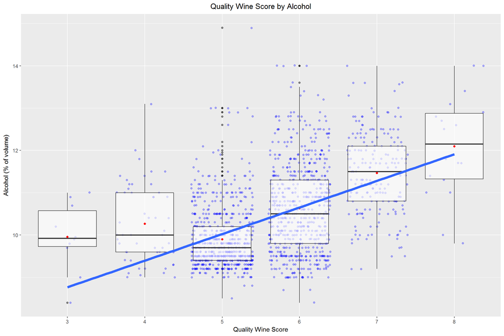

```
##    Min. 1st Qu.  Median    Mean 3rd Qu.    Max.
##    8.40    9.50   10.20   10.42   11.10   14.90
```

```
##    Min. 1st Qu.  Median    Mean 3rd Qu.    Max.
##   3.000   5.000   6.000   5.636   6.000   8.000
```

```
##
##  Pearson's product-moment correlation
##
## data:  redwines$alcohol and redwines$quality
## t = 21.639, df = 1597, p-value < 2.2e-16
## alternative hypothesis: true correlation is not equal to 0
## 95 percent confidence interval:
##  0.4373540 0.5132081
## sample estimates:
##       cor
## 0.4761663
```

**Description Two**

In the plot of alcohol percentage versus quality, we see a moderate positive linear relationship. Out of all the input variables in the dataset, alcohol had the highest correlation of 0.476 to the output variable, wine quality score. Since much of the distribution of alcohol is in the 10.2 to 10.4 range and 5 to 6 for wine quality score, that is seen clearly in the middle two boxplots.

**Plot Three**

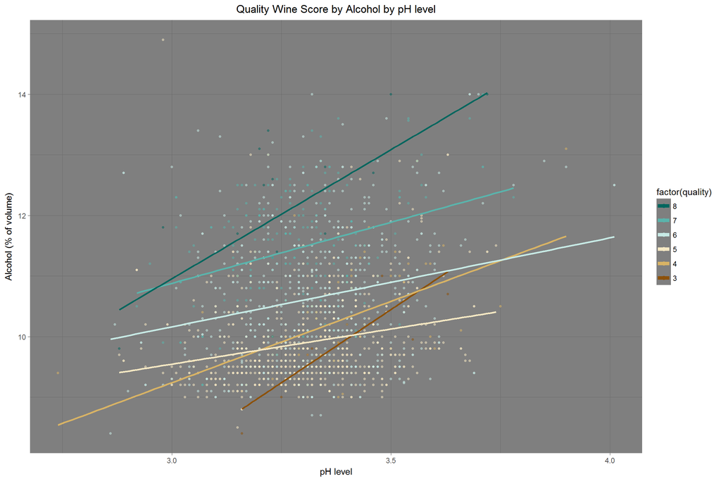

```
##         alcohol quality     pH
## alcohol   1.000   0.476  0.206
## quality   0.476   1.000 -0.058
## pH        0.206  -0.058  1.000
```

**Description Three**

When adding pH to the quality versus alcohol, there seems to be a slight linear relationship between pH level and alcohol percentage. The correlation between pH and alcohol is less than meaningful at 0.206, but we can see for each wine quality score from 3 to 8, the lines are positively sloped. As pH increases, alcohol percentage increases as well. One interesting observation is that each wine quality score’s regression line is almost in order. In other words, the regression line for wine quality score of 3 starts at a certain pH level and alcohol level and slopes upwards. The regression line for wine quality score of 5 starts at a certain pH and higher alcohol level and then slopes upwards. Finally, wine quality score’s regression seems to start at a certain pH level and higher alcohol level and slopes upwards. Recall that the correlation between pH and wine quality score is negligible at -0.05. Perhaps, there is a mix of pH level and alcohol percentage that contributes to a “better” wine and thus a higher score.

### Reflection

The red wines quality dataset contains information on almost 1600 red wines across twelve variables from 2009. All of the variables were input variables except quality which is the output variable. Quality was graded by experts on a scale of 0 (very bad) to 10 (very excellent). I started to explore the invididual variables in the dataset and then started to plot the variables to get an understanding of their distributions. Then I explored the quality variable versus various input variables to see their relationships.

However, I was surprised that the most (albeit moderately) correlated variable to quality was alcohol. But once I started to investigate the invididual variables, it was not too surprising. Many of the variables are related to chemical processes in wine-making. The additions of sulphates, free sulfur dioxide and fixed acidity all relate to processes. The variables volatile acidity, citric acid, pH, chlorides and total sulfur dioxide all relate to taste in some degree.

When I saw correlations less than 0.476 for all variables versus quality, I thought about limitations of the dataset. Since the quality of each wine is evaluated by three experts, it seems like their evaluation process is based on other variables. Perhaps a wine judge maybe interested in qualities such as smell (nose), freshness, sweetness or dryness. Since there are red wines for all occasions and tastes, there could an excellent dry red wine and an excellent not so dry wine. There can be an excellent fruit wine or an excellent no so fruity wine. And it can be the same for the very bad wines. Perhaps, if we knew what the experts are judging on, other variables might be more correlated to quality. Maybe there are more recent datasets that have this information.